# The Normal Distribution

## Introduction

- In this chapter we study the most important type of density curve: the normal curve.
- The normal curve is a symmetric "**bell-shaped**" curve whose exact form we will describe next.
- A distribution represented by a normal curve is called a **normal distribution**.

### Example: serum cholesterol

The relationship between the concentration of cholesterol in the blood and the occurrence of heart disease has been the subject of much research. As part of a government health survey, researchers measured serum cholesterol levels for a large sample of Americans, including children. The distribution for children between $12$ and $14$ years of age can be fairly well approximated by a normal curve with mean $\mu=155$ mg/dl and standard deviation $\sigma=27$ mg/dl. The following figure shows a histogram based on a sample of $431$ children between $12$ and $14$ years old, with the normal curve superimposed.

[figure not shown]

## The Normal Curves

- There are many normal curves; each particular normal curve is characterized by its mean and standard deviation.
- If a random variable $Y$ follows a normal distribution with mean $\mu$ and standard deviation $\sigma$, then it is common to write $Y\sim N(\mu, \sigma)$.
- The probability density function (pdf) of $Y\sim N(\mu, \sigma)$ is $$f(y)=\frac{1}{\sqrt{2\pi}\sigma}e^{-\frac{(y-\mu)^2}{2\sigma^2}},$$ which expresses the height of the normal curve as a function of the position along the horizontal axis. The quantities $e$ and $\pi$ that appear in the formula are constants, with $e$ approximately equal to $2.71$ and $\pi$ approximately equal to 3.14.
- The figure below shows a graph of a normal curve. The shape of the curve is like a symmetric bell, centered at $y = \mu$.
- The direction of curvature is downward (like an inverted bowl) in the central portion of the curve, and upward in the tail portions.
- In principle the curve extends to $+\infty$ and $-\infty$, never actually reaching the $y$-axis; however, the height of the curve is very small for $y$ values more than three standard deviations from the mean.
- The area under the curve is exactly equal to $1$.

[figure not shown]

### Normal curves with different means and SDs

- The location of the normal curve along the $y$-axis is governed by $\mu$ since the curve is centered at $y=\mu$;
- The width and the height of the curve (i.e., whether tall and thin or short and wide) are governed by $\sigma$.

[figure not shown]

## Areas under a Normal Curve

- The standard normal distribution, represented by $Z$, is the normal distribution having a mean of $0$ and a standard deviation of $1$. That is, $Z\sim N(0, 1)$.
- If $X$ is a random variable from a normal distribution with mean $\mu$ and standard deviation $\sigma$, its Z-score (standardization) may be calculated from $X$ by subtracting $\mu$ and dividing by the standard deviation $\sigma$: $$Z=\frac{Y-\mu}{\sigma}.$$
- Z table gives areas under the standard normal curve, with distances along the horizontal axis measured in the Z scale.
- Each area tabled in the body of Z table is the area under the standard normal curve **below** a specified value of $z$, tabled in the margins.
- If we want to find the area *above* a given value of $z$, we subtract the tabulated area from $1$.
- How to find the area between two $z$ values?

[figure not shown]

### The empirical rule for normal distribution

If the variable $Y$ follows a normal distribution, then

- about $68\%$ of the $y$'s are within $\pm1$ SD of the mean.
- about $95\%$ of the $y$'s are within $\pm2$ SDs of the mean.
- about $99.7\%$ of the $y$'s are within $\pm3$ SDs of the mean.

[figure not shown]

### Determining areas for a normal curve

By taking advantage of the standardized scale, we can use $Z$ table to answer detailed questions about any normal population when the population mean and standard deviation are specified.

A professor's exam scores are approximately distributed normally with mean $80$ and standard deviation $5$.

- What is the probability that a student scores an $82$ or less? $0.65542$
- What is the probability that a student scores a $90$ or more? $0.02275$
- What is the probability that a student scores between $74$ and $82$? $0.54035$

### Inverse reading of Z table

We often need to determine corresponding $z$-values when we want to determine a percentile of a normal distribution. For example, suppose we want to find the $70$th percentile of a standard normal distribution. We need to look in Z table for an area of $0.7000$. The closest value is an area of $0.6985$, corresponding to a $z$ value of $0.52$.

- What is the first quartile of the exam score distribution? $76.65$
- What is the $70$th percentile of the exam score distribution? $82.6$

## Assessing Normality

Many statistical procedures are based on having data from a normal population. In this section we consider ways to assess whether it is reasonable to use a normal curve model for a set of data and, if not, how we might proceed.

### Normal quantile plots

A **normal quantile plot** is a special statistical graph that is used to assess normality. We present this statistical tool with an example using the heights (in inches) of a sample of $11$ women, sorted from smallest to largest:

$$61, 62.5, 63, 64, 64.5, 65, 66.5, 67, 68, 68.5, 70.5$$

Based on these data, does it make sense to use a normal curve to model the distribution of women's heights?

[figure not shown]

- sort the data from smallest to largest.
- calculate the adjusted percentiles $100(i-1/2)/n$
- find the corresponding Z scores.
- calculate the theoretical quantiles $\mu+Z\times\sigma$.
- plot the sample quantiles against the theoretical quantiles in a scatterplot.

[figure not shown]

- In this case our plot appears fairly **linear**, suggesting that the observed values generally agree with the theoretical values and the normal model provides a reasonable approximation to the data.
- If the data do not agree with the normal model, then the plot will show strong **nonlinear** patterns such as curvature or S shapes.

### Skewness in normal quantile plots

- Histogram and normal quantile plot of a distribution that is skewed to the left

[figure not shown]

- Histogram and normal quantile plot of a distribution that is skewed to the right

[figure not shown]

- Histogram and normal quantile plot of a distribution that has long tails

[figure not shown]

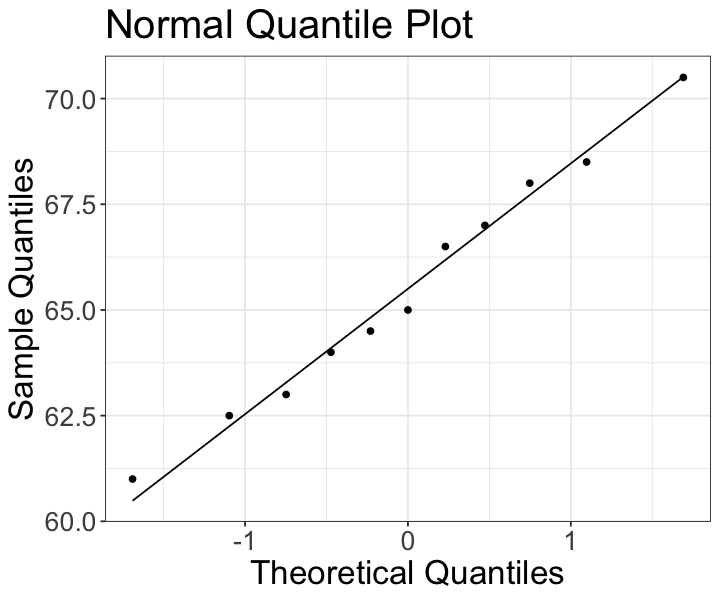

```r
library(ggplot2)

# Create the normal quantile plot using ggplot2
g <- ggplot(data.frame(y = c(61, 62.5, 63, 64,
                             64.5, 65, 66.5, 67,
                             68, 68.5, 70.5)),
            aes(sample = y)) +
    stat_qq() +
    stat_qq_line() +
    labs(x = "Theoretical Quantiles", y = "Sample Quantiles") +
    ggtitle("Normal Quantile Plot") +
    theme_bw() +
    theme(text = element_text(size = 20))
options(repr.plot.width=6, repr.plot.height=5)
g
```

### Transformations for nonnormal data

- Sometimes a histogram or normal quantile plot shows that our data are nonnormal, but a transformation of the data gives us a symmetric, bell-shaped curve.
- In such a situation, we may wish to transform the data and continue our analysis in the new (transformed) scale.
- In general, if the distribution is skewed to the *right* then one of the following transformations should be considered: $$\sqrt{Y}, \log Y, 1/\sqrt{Y}, 1/Y.$$
- These transformations will pull in the long right-hand tail and push out the short left-hand tail, making the distribution more nearly symmetric. **Each of these is more drastic than the one before**. Thus, a square root transformation will change a mildly skewed distribution into a symmetric distribution, but a log transformation may be needed if the distribution is more heavily skewed, and so on.
- If the distribution of a variable $Y$ is skewed to the *left*, then raising $Y$ to a power greater than $1$ can be helpful.